# Self-reported expressibility predicts communicative success: Open dataset, validation, and simulation

## 5.2 Guess similarity

Preregistered model:

`guessability_similarity ~ expressibility + (1 | dyad/participant) + (1 | concept)`

```r
mdl_H1_similarity <- readRDS(paste0(models, "mdl_H1_similarity.rds"))
```

Including expressibility_dutch in the subformulas for φ, zoi, or coi is an option—but it should be done only if you have a strong theoretical or empirical reason to believe that expressibility affects not only the average outcome (the μ component) but also the dispersion or the inflation processes. Considerations:

1. **Theoretical Rationale:**
   - **μ Component (Mean):**  
     Your primary hypothesis (H1) is that higher expressibility leads to higher guessability—that is, it shifts the central tendency of cosine similarity. This is why you include expressibility_dutch in the μ model.
   - **φ Component (Precision):**  
     Adding expressibility_dutch here would imply that expressibility influences how concentrated or spread out the responses are (i.e., the variability around the mean). If you believe that expressibility not only changes the average guessability but also affects the consistency (or uncertainty) of the responses, then including it in φ might be justified.
   - **zoi and coi (Inflation Components):**  
     Including expressibility_dutch in these parts would mean that expressibility also affects the probability of obtaining boundary values (exact 0 or 1). You would do this if you expect that higher expressibility systematically leads to more (or fewer) extreme values (e.g., more responses hitting exactly 1).
2. **Empirical and Practical Considerations:**
   - **Model Complexity:**  
     Adding the predictor to φ, zoi, and coi increases model complexity. This can lead to difficulties in convergence, overfitting, or less stable estimates if the data do not contain enough information for these additional effects.
   - **Interpretability:**  
     The interpretation of effects on φ, zoi, and coi is more subtle. Unless you have a clear rationale, it may be preferable to keep expressibility_dutch only in the μ model and allow the other parameters to remain constant.
   - **Exploratory Analysis:**  
     You might start with the simpler model (predictor only in μ) and then check if there is evidence—through residual analysis, model comparisons, or substantive theory—that expressibility_dutch might also be affecting variability or inflation. Only then would you consider adding it to the other components.

**Conclusion:**

Unless we have a specific reason to believe that expressibility_dutch also influences the dispersion (φ) or the probability of hitting the boundaries (zoi and coi), it is generally advisable to include it only in the μ component. This keeps the model simpler and the interpretation more straightforward, directly addressing your hypothesis about the average effect on guessability.

If we later decide to explore whether expressibility affects other aspects of the distribution, we could extend the model accordingly, but that should be guided by theory or clear empirical indications rather than by default.

Calculate R².

```
##      Estimate   Est.Error       Q2.5      Q97.5
## R2 0.06080538 0.002681202 0.05565882 0.06611153
```

R^2 is 0.0608054 suggesting that 6.0805383% of the variance in the outcome variable are explained by the model.

**Diagnostic plots**:

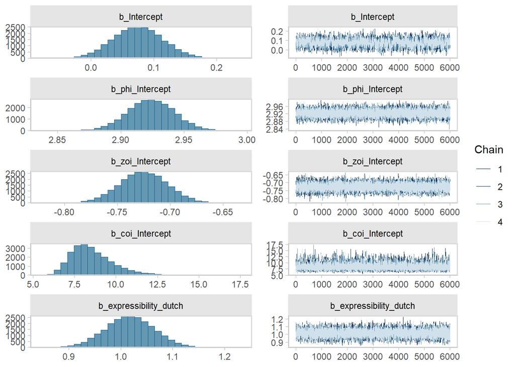

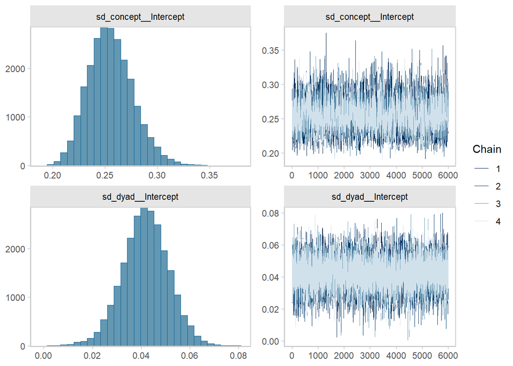

```r
plot(mdl_H1_similarity)
```

**Convergence**: All convergence diagnostics are excellent (Rhat = 1.00).

```r
summary(mdl_H1_similarity)
```

```
##  Family: zero_one_inflated_beta
##   Links: mu = logit; phi = log; zoi = logit; coi = logit
## Formula: cosine_similarity ~ expressibility_dutch + (1 | dyad) + (1 | concept)
##          phi ~ 1
##          zoi ~ 1
##          coi ~ 1
##    Data: df (Number of observations: 8982)
##   Draws: 4 chains, each with iter = 10000; warmup = 4000; thin = 1;
##          total post-warmup draws = 24000
##
## Multilevel Hyperparameters:
## ~concept (Number of levels: 84)
##               Estimate Est.Error l-95% CI u-95% CI Rhat Bulk_ESS Tail_ESS
## sd(Intercept)     0.26      0.02     0.22     0.30 1.00     3352     6318
##
## ~dyad (Number of levels: 71)
##               Estimate Est.Error l-95% CI u-95% CI Rhat Bulk_ESS Tail_ESS
## sd(Intercept)     0.04      0.01     0.02     0.06 1.00     7975     8930
##
## Regression Coefficients:
##                      Estimate Est.Error l-95% CI u-95% CI Rhat Bulk_ESS
## Intercept                0.07      0.04    -0.00     0.15 1.00     2691
## phi_Intercept            2.92      0.02     2.89     2.96 1.00    31363
## zoi_Intercept           -0.73      0.02    -0.77    -0.68 1.00    32753
## coi_Intercept            8.57      1.29     6.64    11.66 1.00    26833
## expressibility_dutch     1.02      0.05     0.93     1.11 1.00    18637
##                      Tail_ESS
## Intercept                6783
## phi_Intercept           17916
## zoi_Intercept           18473
## coi_Intercept           12534
## expressibility_dutch    18363
##
## Draws were sampled using sampling(NUTS). For each parameter, Bulk_ESS
## and Tail_ESS are effective sample size measures, and Rhat is the potential
## scale reduction factor on split chains (at convergence, Rhat = 1).
```

```
## No divergences to plot.
```

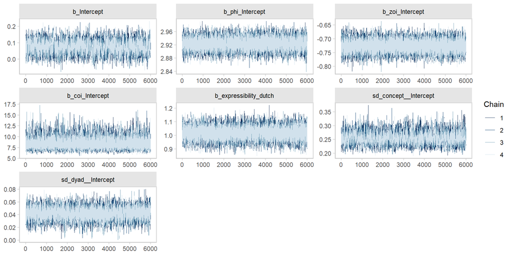

**Figure 30.** Trace of the fitting process. Figure generated using [`R`](https://www.r-project.org/) version 4.4.1 (2024-06-14 ucrt)

```r
mcmc_plot(mdl_H1_similarity, type="trace");
```

**Posterior predictive checks**: Modeling the density of the bimodal distribution is far from ideal.

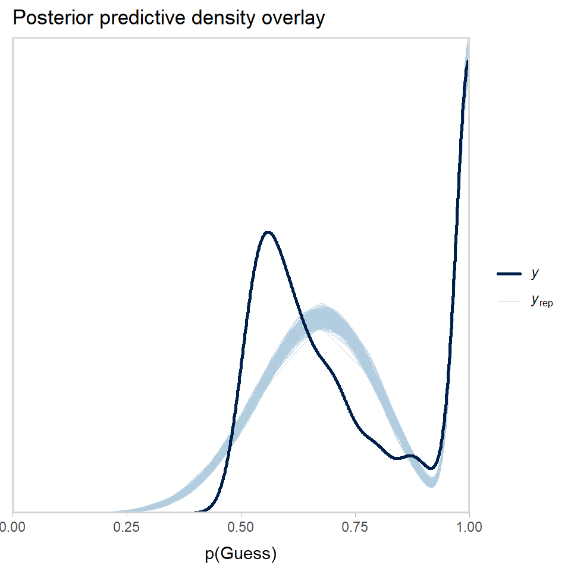

**Figure 31.** Posterior predictive density overlay for n=500 draws. Figure generated using [`R`](https://www.r-project.org/) version 4.4.1 (2024-06-14 ucrt)

```r
pp_check(mdl_H1_similarity, ndraws=500) + xlab('p(Guess)') + ggtitle('Posterior predictive density overlay');
```